# Analyzing the Effect of Discounts on Retail Sales Volume and Revenue Using Seasonal Retail Data

Project Proposal — Group 1

Jake Evans · Mickyas Shawel · Aldo Naranjo · Luis Berumen · Tim Arana

IBM 6540 — Applied Machine Learning for Marketing | Cal Poly Pomona

2026-07-14

## Project Overview

**Main research question:** How does discount percentage affect retail sales volume and revenue when accounting for product category, marketing spend, holidays, and seasonal trends?

[output not shown]

Dataset: [Retail Sales Data with Seasonal Trends & Marketing (Kaggle)](https://www.kaggle.com/datasets/abdullah0a/retail-sales-data-with-seasonal-trends-and-marketing) · Repo: https://github.com/mjshawell/IBM-6540-Group-Project

# Ch1: Introduction

## Problem Definition

- **Audience:** retail managers, ecommerce teams, marketing analysts, and promotion planners who need to evaluate discount strategy
- Retailers frequently use discounts to attract customers, increase demand, and clear inventory
- **The tradeoff:** discounts may increase units sold while reducing revenue per unit
- Without data analysis, retailers may overuse discounts, underuse them, or apply the wrong discount levels to the wrong products or time periods

## Research Objectives

- **RO1 — Seasonality & Timing:** How do sales revenue and units sold vary across seasons, months, and holiday periods?
- **RO2 — Discounts & Volume:** Are higher discount percentages associated with higher units sold?
- **RO3 — Discounts & Revenue:** Do discounts increase sales revenue?
- **RO4 — Category Differences:** Does the effect of discounts differ across product categories?
- **RO5 — Marketing Interaction:** Does marketing spend strengthen the impact of discounts?

Each member leads one RO — confirm assignments on slide 2.

## Importance of the Topic

- Helps retailers decide when discounts are useful versus when they reduce revenue efficiency
- Supports product-level promotional planning by identifying categories that respond well to discounts
- Improves marketing strategy by showing whether discounts perform better with higher marketing spend
- Supports seasonal planning by comparing holiday and non-holiday performance
- Creates a data-driven foundation for pricing, promotion, and revenue optimization decisions

## Background & Hypothesis Directions

| RO | Hypothesis Direction |
| --- | --- |
| RO1 | Revenue and units will vary by season, with holiday periods outperforming regular periods |
| RO2 | Higher discount percentages will be associated with higher units sold |
| RO3 | Discounts may lift revenue up to a point, but higher discounts may not produce proportional gains |
| RO4 | The discount–sales relationship will vary by product category |
| RO5 | Discounts paired with higher marketing spend will show stronger sales outcomes |

# Ch3: Methods

## Dataset Overview & Key Variables

- **Source:** Kaggle secondary dataset (synthetic, designed for analytics practice) — 30,000 transaction-level records, 2022–2024
- **DVs:** Sales Revenue (USD), Units Sold
- **Primary IV:** Discount Percentage (0–20%)
- **Additional predictors:** Marketing Spend (USD), Product Category, Store Location, Day of the Week, Holiday Effect, Date

## Population, Sampling & Data Collection

- **Population represented:** transaction-level retail sales records across stores, locations, and product categories
- The dataset is synthetic; it stands in for multi-location retail chains that run discount and marketing programs
- **Sampling:** secondary data collection — records are already collected and will be prepared for analysis in R

## Data Wrangling Plan

- **From records to data:** import CSV with `readr::read_csv()`; each row = one retail sales record
- **Tidying:** `janitor::clean_names()`; check missing values, duplicates, and outliers; convert `Date` to date type; standardize categorical variables (category, location, day, holiday)
- **Transforming:**
  - `month`, `year`, `season` derived from `Date`
  - `discount_group` from `discount_percentage` — No discount (0%), Low (1–10%), High (11–20%)
  - Group summaries of revenue and units by discount group, category, day, and holiday status

# RO1: Seasonality & Timing — Lead: Jake Evans

## RO1: Plan

- **Objective:** How do sales revenue and units sold vary across seasons, months, and holiday periods?
- **IVs:** month, season (derived from `Date`), Day of the Week, Holiday Effect
- **DVs:** Sales Revenue, Units Sold
- **Wrangling:** extract month/season from `Date`; aggregate revenue and units by month; compare holiday vs. non-holiday periods
- **Visualization:** monthly revenue line chart; holiday comparison bars; day-of-week heatmap; seasonal summary table

## RO1: Monthly Revenue Trend

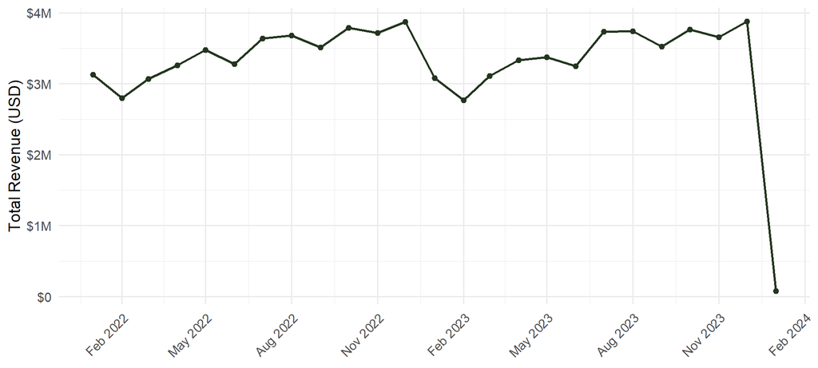

## RO1: Revenue by Season — Holiday vs. Non-Holiday

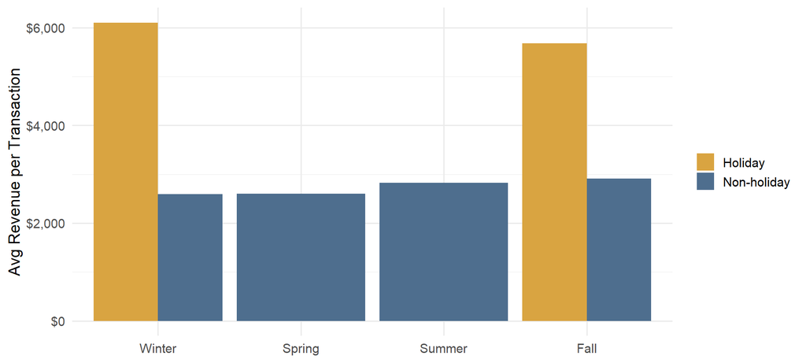

## RO1: Revenue by Day of Week & Month

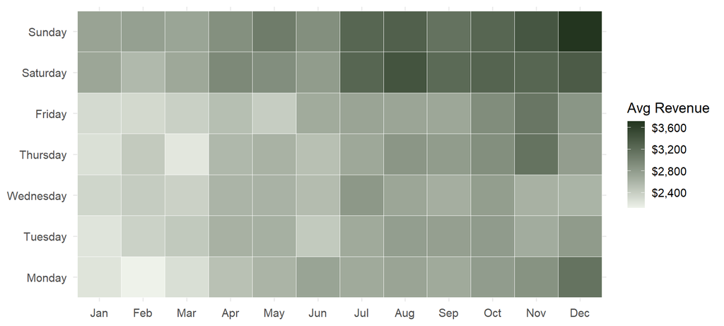

## RO1: Seasonal Summary

| Season | Transactions | Avg Revenue | Avg Units |
| --- | --- | --- | --- |
| Winter | 7450 | $2,631.59 | 5.95 |
| Spring | 7544 | $2,600.59 | 5.82 |
| Summer | 7544 | $2,824.12 | 6.29 |
| Fall | 7462 | $2,942.36 | 6.59 |

# Research Objective Plans

- **Objective:** Analyze whether higher discount percentages are associated with higher units sold
- **IV:** Discount Percentage · **DV:** Units Sold
- **Controls:** Product Category, Store Location, Day of Week, Holiday Effect
- **Wrangling plan:** clean discount variable; group into No / Low / High discount; summarize units sold by group
- **Visualization plan:** scatterplot with trend line; boxplot of units sold by discount group; bar chart of average units sold by group

# RO3: Discounts & Revenue — Lead: Luis Berumen

## RO3: Plan

- **Objective:** Examine the relationship between discount percentage and sales revenue.
- **IV:** Discount Percentage
- **DV:** Sales Revenue (USD)
- **Controls:** Units Sold, Product Category, Marketing Spend
- **Wrangling:** Create discount groups; calculate transaction count, average revenue, and total revenue.
- **Visualizations:** Scatterplot, grouped bar chart, and revenue summary table.

## RO3: Discount Percentage vs. Sales Revenue

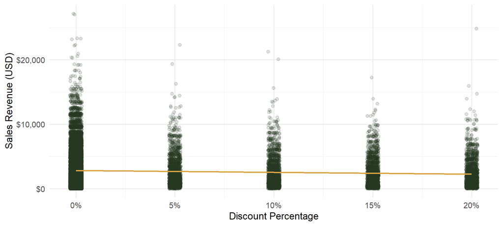

## RO3: Revenue by Product Category and Discount Group

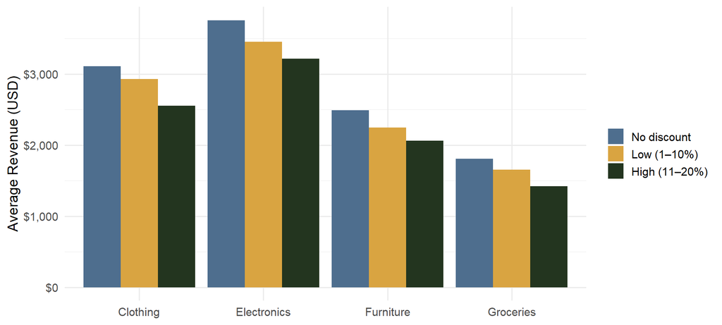

## RO3: Revenue Summary

| Discount Group | Transactions | Avg Revenue | Total Revenue |
| --- | --- | --- | --- |
| No discount | 22846 | $2,834.86 | $64,765,282 |
| Low (1–10%) | 3608 | $2,599.89 | $9,380,408 |
| High (11–20%) | 3546 | $2,351.83 | $8,339,598 |

- **Objective:** Compare the effect of discounts across product categories
- **IV:** Discount Percentage · **DV:** Units Sold / Sales Revenue
- **Moderator:** Product Category (Clothing, Electronics, Furniture, Groceries)
- **Wrangling plan:** group records by product category and discount group; compute average revenue and units sold
- **Visualization plan:** faceted bar charts by category; category-level comparison table; grouped bar chart

- **Objective:** Analyze whether marketing spend strengthens the impact of discounts
- **IVs:** Discount Percentage, Marketing Spend (USD) · **DV:** Sales Revenue / Units Sold
- **Possible interaction:** Discount Percentage × Marketing Spend
- **Wrangling plan:** create marketing spend groups; summarize outcomes by marketing group and discount group; optional interaction model
- **Visualization plan:** scatterplot of marketing spend vs. sales; grouped bar chart by discount group; interaction plot

# Conclusion

## Planned Analysis & Expected Contribution

- **Procedure:** wrangle once (shared setup), then group summaries and visualizations per RO; optional model direction — regression of units/revenue on discount, marketing spend, and controls
- **What the audience gains:**
  - When discounts are useful vs. when they erode revenue efficiency
  - Which product categories respond to discounts
  - Whether marketing spend amplifies discount effects
  - How seasonal and holiday timing shapes discount performance
- **Deliverable becomes actionable:** discount levels, category priorities, marketing pairing, and a seasonal promotion calendar

## Conclusion & Next Steps

- **Problem:** discounts drive volume but may erode revenue — retailers need evidence, not habit
- **Approach:** five ROs covering timing, volume, revenue, category, and marketing interaction on 30,000 retail transactions
- **Next steps toward Ch4 (Results) and Ch5 (Recommendations):** each lead finalizes summaries, visualizations, and interpretation for their RO

## Thank You

**Questions?**

Group 1 — IBM 6540 | Summer 2026

Repo: https://github.com/mjshawell/IBM-6540-Group-Project